# Midterm 1 W24

Iliya Voytsyshyn

2024-02-06

## Instructions

Answer the following questions and complete the exercises in RMarkdown. Please embed all of your code and push your final work to your repository. Your code must be organized, clean, and run free from errors. Remember, you must remove the `#` for any included code chunks to run. Be sure to add your name to the author header above.

Your code must knit in order to be considered. If you are stuck and cannot answer a question, then comment out your code and knit the document. You may use your notes, labs, and homework to help you complete this exam. Do not use any other resources- including AI assistance.

Don’t forget to answer any questions that are asked in the prompt!

Be sure to push your completed midterm to your repository. This exam is worth 30 points.

## Background

In the data folder, you will find data related to a study on wolf mortality collected by the National Park Service. You should start by reading the `README_NPSwolfdata.pdf` file. This will provide an abstract of the study and an explanation of variables.

The data are from: Cassidy, Kira et al. (2022). Gray wolf packs and human-caused wolf mortality. [Dryad](https://doi.org/10.5061/dryad.mkkwh713f).

## Load the libraries

```r
library("tidyverse")
library("janitor")
```

## Load the wolves data

In these data, the authors used `NULL` to represent missing values. I am correcting this for you below and using `janitor` to clean the column names.

```r
wolves <- read.csv("data/NPS_wolfmortalitydata.csv", na = c("NULL")) %>% clean_names()
```

## Questions

Problem 1. (1 point) Let’s start with some data exploration. What are the variable (column) names?

```r
names(wolves)
```

```
##  [1] "park"         "biolyr"       "pack"         "packcode"     "packsize_aug"
##  [6] "mort_yn"      "mort_all"     "mort_lead"    "mort_nonlead" "reprody1"
## [11] "persisty1"
```

Problem 2. (1 point) Use the function of your choice to summarize the data and get an idea of its structure.

```r
glimpse(wolves)
```

```
## Rows: 864
## Columns: 11
## $ park         <chr> "DENA", "DENA", "DENA", "DENA", "DENA", "DENA", "DENA", "…
## $ biolyr       <int> 1996, 1991, 2017, 1996, 1992, 1994, 2007, 2007, 1995, 200…
## $ pack         <chr> "McKinley River1", "Birch Creek N", "Eagle Gorge", "East …
## $ packcode     <int> 89, 58, 71, 72, 74, 77, 101, 108, 109, 53, 63, 66, 70, 72…
## $ packsize_aug <dbl> 12, 5, 8, 13, 7, 6, 10, NA, 9, 8, 7, 11, 0, 19, 15, 12, 1…
## $ mort_yn      <int> 1, 1, 1, 1, 1, 1, 1, 1, 1, 1, 1, 1, 1, 1, 1, 1, 1, 1, 1, …
## $ mort_all     <int> 4, 2, 2, 2, 2, 2, 2, 2, 2, 1, 1, 1, 1, 1, 1, 1, 1, 1, 1, …
## $ mort_lead    <int> 2, 2, 0, 0, 0, 0, 1, 2, 1, 1, 1, 0, 0, 0, 1, 1, 1, 0, 0, …
## $ mort_nonlead <int> 2, 0, 2, 2, 2, 2, 1, 0, 1, 0, 0, 1, 1, 1, 0, 0, 0, 1, 1, …
## $ reprody1     <int> 0, 0, NA, 1, NA, 0, 0, 1, 0, 1, 0, 1, 0, 1, 1, 1, 1, 1, 1…
## $ persisty1    <int> 0, 0, 1, 1, 1, 1, 0, 1, 0, 1, 0, 1, 0, 1, 1, 1, 1, 1, 1, …
```

Problem 3. (3 points) Which parks/ reserves are represented in the data? Don’t just use the abstract, pull this information from the data.

```r
table(wolves$park)
```

```
##
## DENA GNTP  VNP  YNP YUCH
##  340   77   48  248  151
```

Problem 4. (4 points) Which park has the largest number of wolf packs?

```r
park_large <- wolves %>%
  group_by(park) %>%
  summarize(n_wolf_pack=n(), .groups= 'keep') %>%
  arrange(desc(n_wolf_pack)) %>%
  head(1)
park_large
```

```
## # A tibble: 1 × 2
## # Groups:   park [1]
##   park  n_wolf_pack
##   <chr>       <int>
## 1 DENA          340
```

Problem 5. (4 points) Which park has the highest total number of human-caused mortalities `mort_all`?

```r
high_death <- wolves %>%
  group_by(park) %>%
  select(park, mort_all) %>%
  filter(mort_all == 1) %>%
  summarise(n_park=n()) %>%
  arrange(desc(n_park)) %>%
  head(1)
high_death
```

```
## # A tibble: 1 × 2
##   park  n_park
##   <chr>  <int>
## 1 DENA      44
```

The wolves in [Yellowstone National Park](https://www.nps.gov/yell/learn/nature/wolf-restoration.htm) are an incredible conservation success story. Let’s focus our attention on this park.

Problem 6. (2 points) Create a new object “ynp” that only includes the data from Yellowstone National Park.

```r
ynp <- wolves %>%
  filter(park == "YNP")
```

Problem 7. (3 points) Among the Yellowstone wolf packs, the [Druid Peak Pack](https://www.pbs.org/wnet/nature/in-the-valley-of-the-wolves-the-druid-wolf-pack-story/209/) is one of most famous. What was the average pack size of this pack for the years represented in the data?

```r
ynp %>%
  filter(pack == "druid") %>%
  #group_by(biolyr) %>%
  summarise(mean_pack_size=mean(packsize_aug),
            n_pack=n())
```

```
##   mean_pack_size n_pack
## 1       13.93333     15
```

Problem 8. (4 points) Pack dynamics can be hard to predict- even for strong packs like the Druid Peak pack. At which year did the Druid Peak pack have the largest pack size? What do you think happened in 2010?

```r
ynp %>%
  filter(pack == "druid") %>%
  group_by(biolyr) %>%
  summarise(mean_pack_size=mean(packsize_aug)) %>%
  arrange(desc(mean_pack_size)) %>%
  slice(1)
```

```
## # A tibble: 1 × 2
##   biolyr mean_pack_size
##    <int>          <dbl>
## 1   2001             37
```

```r
ynp %>%
  filter(pack == "druid") %>%
  group_by(pack) %>%
  filter(biolyr == 2010) %>%
  is.na()
```

```
##       park biolyr  pack packcode packsize_aug mort_yn mort_all mort_lead
## [1,] FALSE  FALSE FALSE    FALSE        FALSE   FALSE    FALSE     FALSE
##      mort_nonlead reprody1 persisty1
## [1,]        FALSE    FALSE      TRUE
```

Here we can see that for the year 2010 there is no information (NA) about presistence for druid pack. Also through some research I found that [Druid Pack](https://yollowstonewolves.fandom.com/wiki/Druids_Pack#:~:text=The%20Druids%20were%20down%20to,his%20cattle%20out%20of%20desperation.) has been at the edge of extinction since the population “were down to one wolf”. We can confirm this infromation if we will look at the data:

```r
ynp %>%
  filter(pack == "druid") %>%
  group_by(pack) %>%
  filter (between(biolyr, 2009, 2010))
```

```
## # A tibble: 2 × 11
## # Groups:   pack [1]
##   park  biolyr pack  packcode packsize_aug mort_yn mort_all mort_lead
##   <chr>  <int> <chr>    <int>        <dbl>   <int>    <int>     <int>
## 1 YNP     2009 druid       26           12       0        0         0
## 2 YNP     2010 druid       26            0       0        0         0
## # ℹ 3 more variables: mort_nonlead <int>, reprody1 <int>, persisty1 <int>
```

Problem 9. (5 points) Among the YNP wolf packs, which one has had the highest overall persistence `persisty1` for the years represented in the data? Look this pack up online and tell me what is unique about its behavior- specifically, what prey animals does this pack specialize on?

```r
#ynp %>%
 # group_by(pack) %>%
 # select(park, pack, persisty1, packsize_aug) %>%
 # filter(persisty1 == 1 & packsize_aug != "NA") %>%
 # arrange(desc(packsize_aug)) %>%
 # head(1)
```

```r
ynp %>%
  group_by(pack) %>%
  select(park, biolyr, pack, persisty1, packsize_aug) %>%
  filter(persisty1 == 1) %>%
  summarise(n_pack=n()) %>%
  arrange(desc(n_pack)) %>%
  head(1)
```

```
## # A tibble: 1 × 2
##   pack    n_pack
##   <chr>    <int>
## 1 mollies     26
```

Problem 10. (3 points) Perform one analysis or exploration of your choice on the `wolves` data. Your answer needs to include at least two lines of code and not be a summary function.

```r
my_analysis <- wolves %>%
  group_by(pack) %>%
  summarise(mean_death_other=mean(mort_all, na.rm = T),
           mean_death_lead=mean(mort_lead, na.rm = T),
            n=n()) %>%
  mutate(death_relation = mean_death_lead/mean_death_other) %>%
  arrange(desc(death_relation))
my_analysis
```

```
## # A tibble: 184 × 5
##    pack           mean_death_other mean_death_lead     n death_relation
##    <chr>                     <dbl>           <dbl> <int>          <dbl>
##  1 100 Mile                  0.125           0.125     8              1
##  2 1155Mgroup                1               1         1              1
##  3 963Fgroup                 1               1         1              1
##  4 Birch Creek N             2               2         1              1
##  5 Castle Rocks2             0.5             0.5       2              1
##  6 Edwards Creek2            0.25            0.25      8              1
##  7 Fourth of July            2               2         1              1
##  8 Hanna Creek               1               1         1              1
##  9 Hauke Creek               0.5             0.5       2              1
## 10 John Hansen               0.2             0.2       5              1
## # ℹ 174 more rows
```

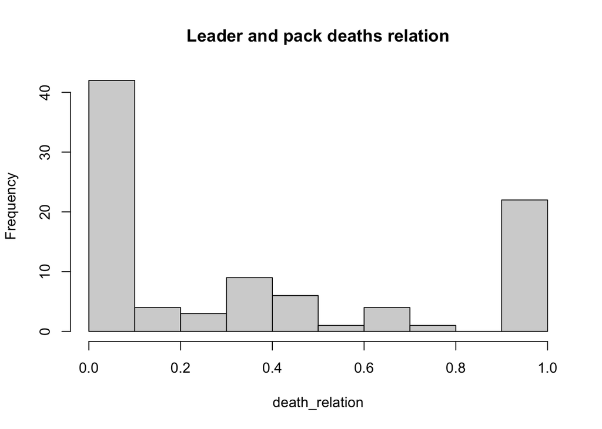

```r
my_analysis$death_relation <- as.numeric(my_analysis$death_relation)
hist(my_analysis$death_relation, main = "Leader and pack deaths relation", xlab = "death_relation") #here I tried to do the histogram to display the death_relation for each pack, but I did not know how to represent the pack names on the histogram, since we did not go over it.
```